# R Notebook

# 1. Data Prepare

## - Load ggplot2 package

## - Downlaod the data

```r
download.file("https://raw.githubusercontent.com/biocorecrg/CRG_RIntroduction/master/ex12_normalized_intensities.csv", "ex12_normalized_intensities.csv", method="curl")
```

```
  % Total    % Received % Xferd  Average Speed   Time    Time     Time  Current
                                 Dload  Upload   Total   Spent    Left  Speed

  0     0    0     0    0     0      0      0 --:--:-- --:--:-- --:--:--     0
100  110k  100  110k    0     0   212k      0 --:--:-- --:--:-- --:--:--  213k
```

Read file into object “project1” (remember the input/output tutorial!)

About this file:

It is comma separated (csv format). The first row is the header. Take the row names from the first column.

```r
project1 <- read.table("ex12_normalized_intensities.csv",
  sep=",",
  header=TRUE,
  row.names = 1)
```

# 2. Data Visualization

Using ggplot, create a simple scatter plot representing gene expression of “sampleB” on the x-axis and “sampleH” on the y-axis.

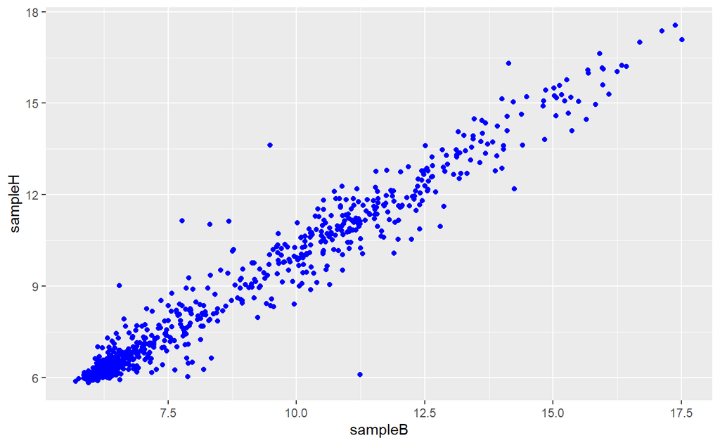

Add a column to the data frame “project1” (call this column “expr_limits”), that will be filled the following way:

if the expression of a gene is > 13 in both sampleB and sampleH, set to the value in “expr_limits” to “high” if the expression of a gene is < 6 in both sampleB and sampleH, set it to “low” if different, set it to “normal”.

```r
project1$expr_limits <- "normal"
# "high" if project1$sampleB > 13 and project1$sampleH > 13
project1$expr_limits[project1$sampleB > 13 & project1$sampleH > 13] <- "high"
# "low" if project1$sampleB < 6 and project1$sampleH < 6
project1$expr_limits[project1$sampleB < 6 & project1$sampleH < 6] <- "low"
```

Color the points of the scatter plot according to the newly created column “expr_limits”. Save that plot in the object “p”

```r
p <- ggplot(data = project1, mapping = aes(x = sampleB, y = sampleH, colour = expr_limits)) +
  geom_point()
```

Add a layer to “p” in order to change the points colors to blue (for low), grey (for normal) and red (for high). Save this plot in the object “p2”.

```r
p2 <- p + scale_color_manual(values=c("red", "blue", "grey"))
```

## 2.2 Box plot

Convert “project1” from a wide format to a long format: save in the object “project_long”

```r
library(reshape2)
project_long <- melt(data=project1)
```

Produce a boxplot of the expression of all samples (i.e. each sample is represented by a box)

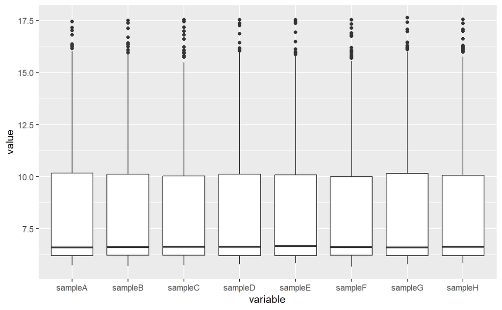

Modify the previous boxplot so as to obtain 3 “sub-boxplots” per sample, each representing the expression of either “low”, “normal” or “high” genes.

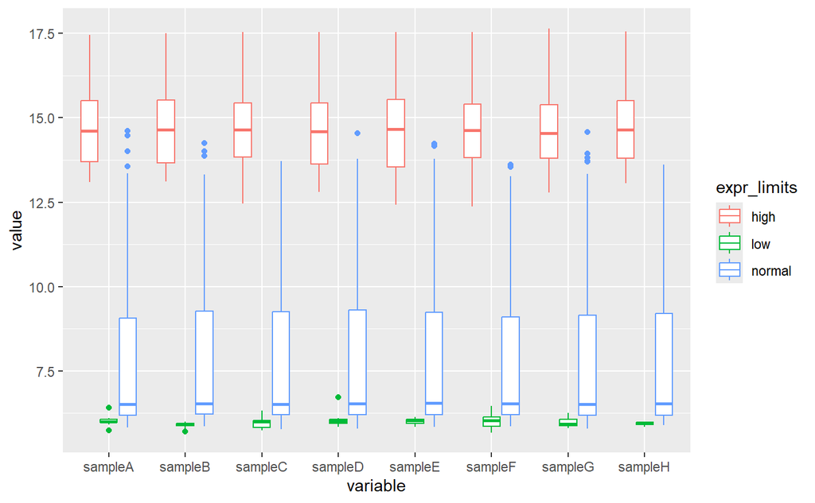

Rotate the x-axis labels (90 degrees angle)

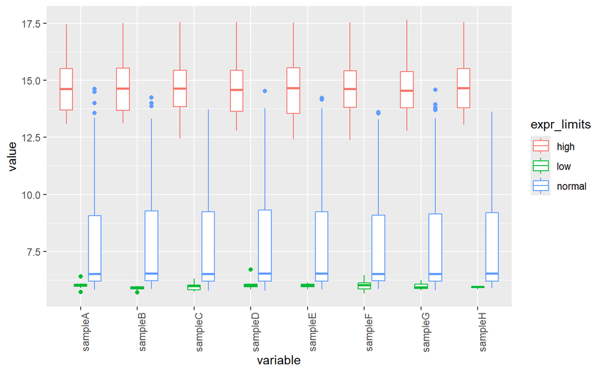

```r
ggplot(data=project_long, mapping=aes(x=variable, y=value, color=expr_limits)) +
  geom_boxplot() +
  theme(axis.text.x = element_text(angle = 90))
```

Finally, add a title of your choice to the plot.

```r
ggplot(data=project_long, mapping=aes(x=variable, y=value, color=expr_limits)) +
  geom_boxplot() +
  theme(axis.text.x = element_text(angle = 90)) +
  ggtitle("My boxplots")
```

[output not shown]

## 2.3 Bar plot

Produce a bar plot of how many low/normal/high genes are in the column “expr_limits” of “project1”.

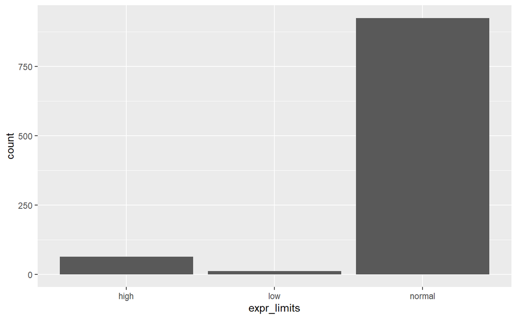

```r
ggplot(data=project1, mapping=aes(x= expr_limits)) +
  geom_bar()
```

Add an horizontal line at counts 250 (y-axis). Save the plot in the object “bar”

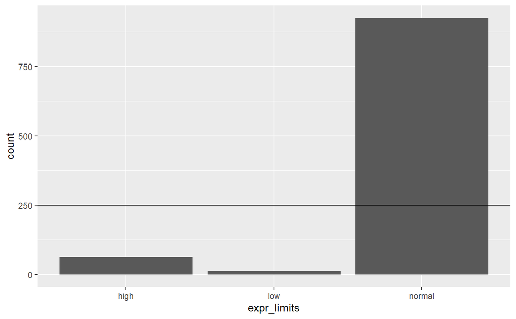

```r
ggplot(data=project1, mapping=aes(x=expr_limits)) +
  geom_bar() +
  geom_hline(yintercept=250)
```

```r
bar <- ggplot(data=project1, mapping=aes(x=expr_limits)) +
  geom_bar() +
  geom_hline(yintercept=250)
```

Swap the x and y axis. Save in object “bar2”.

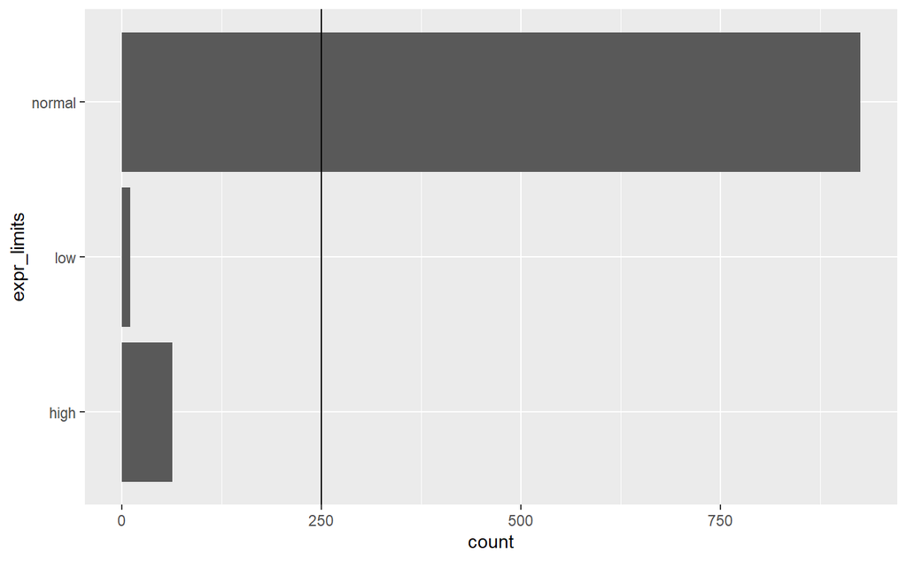

## 2.4 Histogram

Create a simple histogram using project_long (column “value”).

[output not shown]

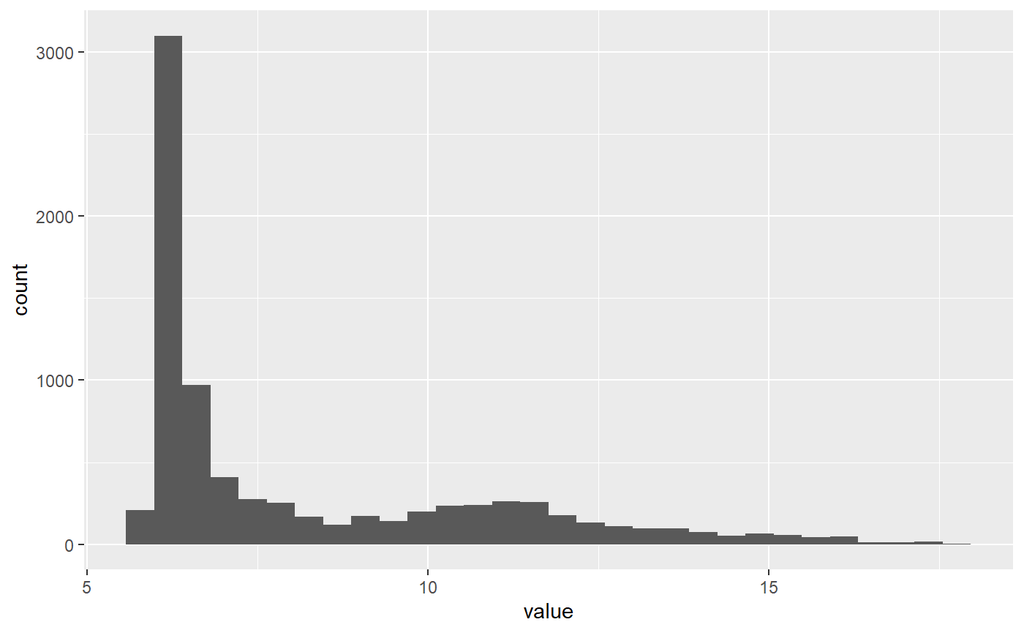

```r
ggplot(data=project_long, mapping=aes(x=value)) +
  geom_histogram()
```

Notice that you get the following warning message” stat_bin() using bins = 30. Pick better value with binwidth.

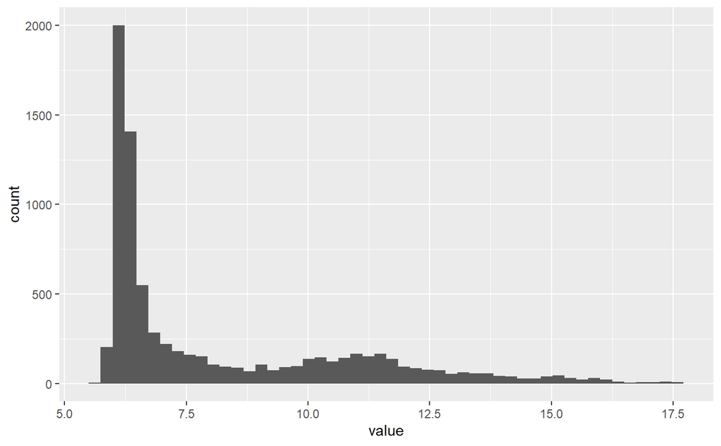

```r
ggplot(data=project_long, mapping=aes(x=value)) +
  geom_histogram(bins=50)
```

he histogram plots the expression values for All samples. Change the plot so as to obtain one histograms per sample.

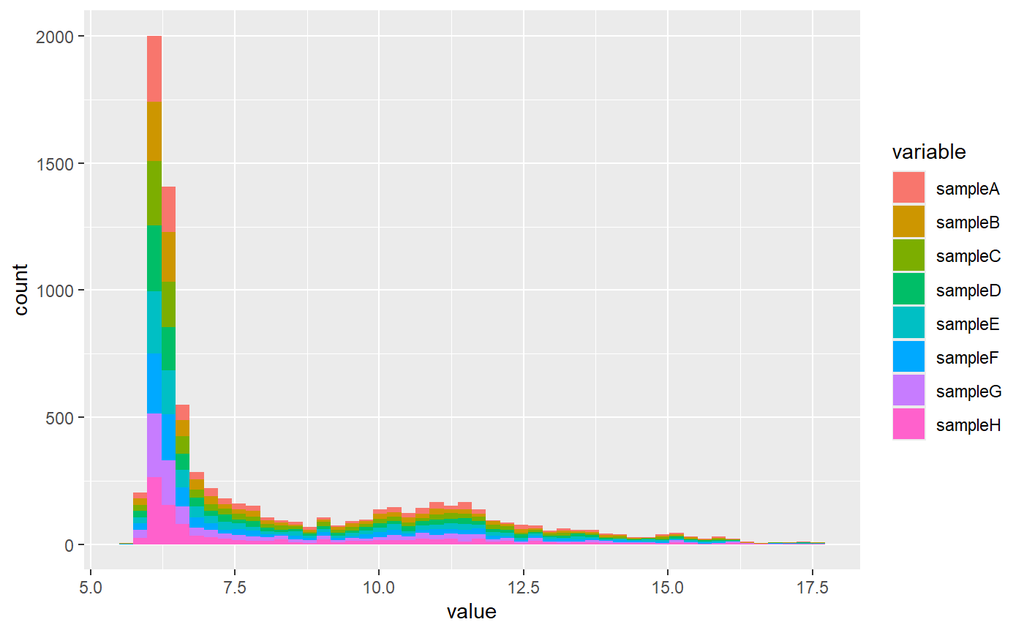

```r
ggplot(data=project_long, mapping=aes(x=value, fill=variable)) +
  geom_histogram(bins=50)
```

Change argument “position” to “dodge”.

[output not shown]

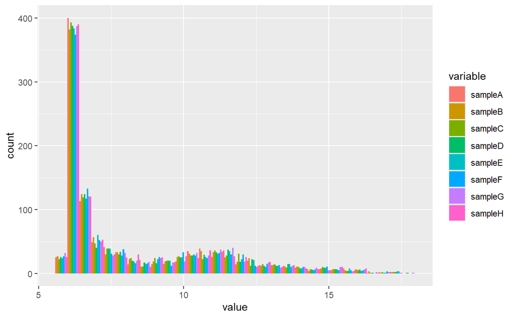

```r
hist1 <- ggplot(data=project_long, mapping=aes(x=value, fill=variable)) +
  geom_histogram(position="dodge")
hist1
```

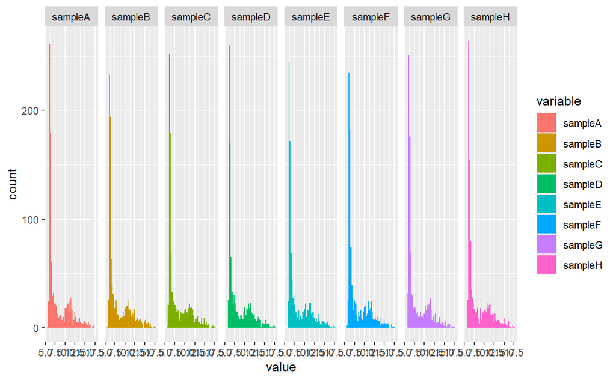

```r
hist2 <- ggplot(data=project_long, mapping=aes(x=value, fill=variable)) +
  geom_histogram(bins=50) +
  facet_grid(~variable)

hist2
```

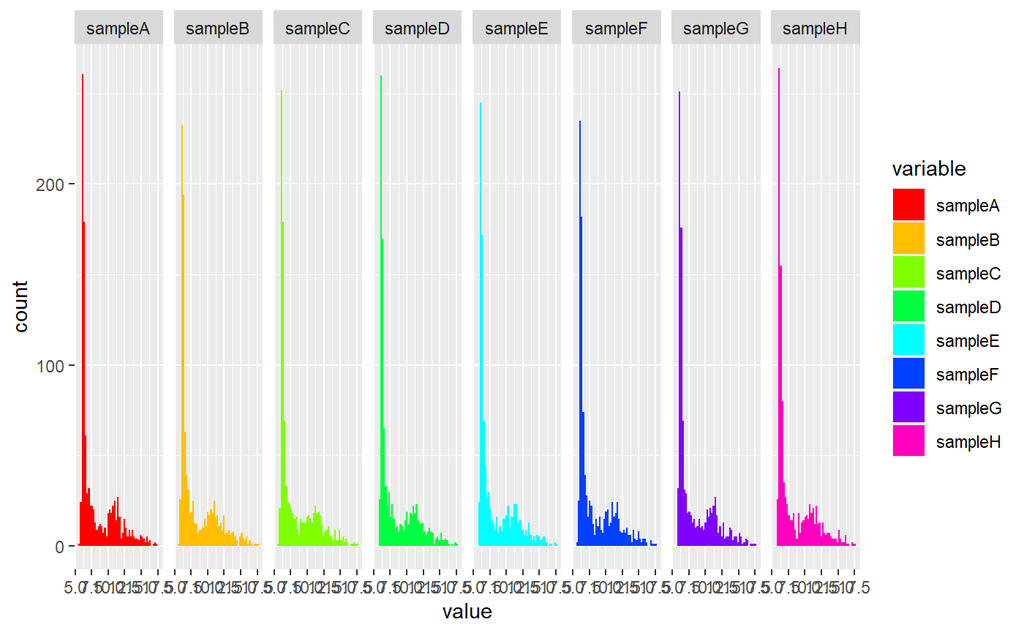

```r
hist3 <- hist2 + scale_fill_manual(values=rainbow(8))

hist3
```

Add the xlim() layer.

[figure not shown]

```r
hist4
```